# Data Visualization Project

### Importing the essential Libraries

```python
import pandas as pd
import numpy as np
import matplotlib.pyplot as plt
```

### Importing The Dataset

```python
data = pd.read_csv('carbon.csv')
```

### Data Pre-processing

```python
data_t = data.transpose()
```

```python
l=[i for i in range(data_t.shape[0])]
```

```python
new_column=data_t.index
data_t.set_index([pd.Index(l)],inplace=True)
data_t["years"]=new_column
data_t.head()
```

|  | 0 | 1 | 2 | 3 | 4 | 5 | 6 | 7 | 8 | 9 | ... | 256 | 257 | 258 | 259 | 260 | 261 | 262 | 263 | 264 | years |
| --- | --- | --- | --- | --- | --- | --- | --- | --- | --- | --- | --- | --- | --- | --- | --- | --- | --- | --- | --- | --- | --- |
| 0 | Country Name | Aruba | Afghanistan | Angola | Albania | Andorra | Arab World | United Arab Emirates | Argentina | Armenia | ... | Vietnam | Vanuatu | World | Samoa | Kosovo | Yemen, Rep. | South Africa | Zambia | Zimbabwe | Unnamed: 0 |
| 1 | NaN | NaN | 0.0460567 | 0.100835 | 1.25819 | NaN | 0.645736 | 0.119035 | 2.38334 | NaN | ... | 0.229314 | NaN | 3.09916 | 0.135028 | NaN | 0.683679 | 5.72722 | NaN | NaN | 1960 |
| 2 | NaN | NaN | 0.0535888 | 0.0822038 | 1.37419 | NaN | 0.687465 | 0.109141 | 2.45855 | NaN | ... | 0.237233 | NaN | 3.07002 | 0.163552 | NaN | 0.494324 | 5.83262 | NaN | NaN | 1961 |
| 3 | NaN | NaN | 0.0737208 | 0.210531 | 1.43996 | NaN | 0.763574 | 0.163533 | 2.53845 | NaN | ... | 0.2695 | 0.594994 | 3.14096 | 0.158366 | NaN | 0.71013 | 5.88717 | NaN | NaN | 1962 |
| 4 | NaN | NaN | 0.0741607 | 0.202737 | 1.18168 | NaN | 0.878238 | 0.175833 | 2.33069 | NaN | ... | 0.255306 | 0.471835 | 3.24511 | 0.184026 | NaN | 0.525293 | 5.96134 | NaN | NaN | 1963 |

5 rows × 266 columns

```python
new_header = data_t.iloc[0]
data_t = data_t[1:]
data_t.columns = new_header
```

```python
data_t.head()
```

|  | Country Name | Aruba | Afghanistan | Angola | Albania | Andorra | Arab World | United Arab Emirates | Argentina | Armenia | ... | Vietnam | Vanuatu | World | Samoa | Kosovo | Yemen, Rep. | South Africa | Zambia | Zimbabwe | Unnamed: 0 |
| --- | --- | --- | --- | --- | --- | --- | --- | --- | --- | --- | --- | --- | --- | --- | --- | --- | --- | --- | --- | --- | --- |
| 1 | NaN | NaN | 0.0460567 | 0.100835 | 1.25819 | NaN | 0.645736 | 0.119035 | 2.38334 | NaN | ... | 0.229314 | NaN | 3.09916 | 0.135028 | NaN | 0.683679 | 5.72722 | NaN | NaN | 1960 |
| 2 | NaN | NaN | 0.0535888 | 0.0822038 | 1.37419 | NaN | 0.687465 | 0.109141 | 2.45855 | NaN | ... | 0.237233 | NaN | 3.07002 | 0.163552 | NaN | 0.494324 | 5.83262 | NaN | NaN | 1961 |
| 3 | NaN | NaN | 0.0737208 | 0.210531 | 1.43996 | NaN | 0.763574 | 0.163533 | 2.53845 | NaN | ... | 0.2695 | 0.594994 | 3.14096 | 0.158366 | NaN | 0.71013 | 5.88717 | NaN | NaN | 1962 |
| 4 | NaN | NaN | 0.0741607 | 0.202737 | 1.18168 | NaN | 0.878238 | 0.175833 | 2.33069 | NaN | ... | 0.255306 | 0.471835 | 3.24511 | 0.184026 | NaN | 0.525293 | 5.96134 | NaN | NaN | 1963 |
| 5 | NaN | NaN | 0.0861736 | 0.21356 | 1.11174 | NaN | 1.00305 | 0.132825 | 2.55344 | NaN | ... | 0.320838 | 0.864439 | 3.36138 | 0.208112 | NaN | 0.644143 | 6.33234 | 0.946606 | 1.0349 | 1964 |

5 rows × 266 columns

```python
data_t.drop(["Country Name"], axis = 1, inplace = True)
```

```python
data_t.head()
```

|  | Aruba | Afghanistan | Angola | Albania | Andorra | Arab World | United Arab Emirates | Argentina | Armenia | American Samoa | ... | Vietnam | Vanuatu | World | Samoa | Kosovo | Yemen, Rep. | South Africa | Zambia | Zimbabwe | Unnamed: 0 |
| --- | --- | --- | --- | --- | --- | --- | --- | --- | --- | --- | --- | --- | --- | --- | --- | --- | --- | --- | --- | --- | --- |
| 1 | NaN | 0.0460567 | 0.100835 | 1.25819 | NaN | 0.645736 | 0.119035 | 2.38334 | NaN | NaN | ... | 0.229314 | NaN | 3.09916 | 0.135028 | NaN | 0.683679 | 5.72722 | NaN | NaN | 1960 |
| 2 | NaN | 0.0535888 | 0.0822038 | 1.37419 | NaN | 0.687465 | 0.109141 | 2.45855 | NaN | NaN | ... | 0.237233 | NaN | 3.07002 | 0.163552 | NaN | 0.494324 | 5.83262 | NaN | NaN | 1961 |
| 3 | NaN | 0.0737208 | 0.210531 | 1.43996 | NaN | 0.763574 | 0.163533 | 2.53845 | NaN | NaN | ... | 0.2695 | 0.594994 | 3.14096 | 0.158366 | NaN | 0.71013 | 5.88717 | NaN | NaN | 1962 |
| 4 | NaN | 0.0741607 | 0.202737 | 1.18168 | NaN | 0.878238 | 0.175833 | 2.33069 | NaN | NaN | ... | 0.255306 | 0.471835 | 3.24511 | 0.184026 | NaN | 0.525293 | 5.96134 | NaN | NaN | 1963 |
| 5 | NaN | 0.0861736 | 0.21356 | 1.11174 | NaN | 1.00305 | 0.132825 | 2.55344 | NaN | NaN | ... | 0.320838 | 0.864439 | 3.36138 | 0.208112 | NaN | 0.644143 | 6.33234 | 0.946606 | 1.0349 | 1964 |

5 rows × 265 columns

```python
data_t.rename(columns={'Unnamed:0': 'Years'}, inplace=True)
```

```python
data_t.shape
#len(data_t.columns)
```

```
(55, 265)
```

## Displaying theDataset for CO2 emission by each country over the years

```python
data_t.head()
```

|  | Aruba | Afghanistan | Angola | Albania | Andorra | Arab World | United Arab Emirates | Argentina | Armenia | American Samoa | ... | Vietnam | Vanuatu | World | Samoa | Kosovo | Yemen, Rep. | South Africa | Zambia | Zimbabwe | Unnamed: 0 |
| --- | --- | --- | --- | --- | --- | --- | --- | --- | --- | --- | --- | --- | --- | --- | --- | --- | --- | --- | --- | --- | --- |
| 1 | NaN | 0.0460567 | 0.100835 | 1.25819 | NaN | 0.645736 | 0.119035 | 2.38334 | NaN | NaN | ... | 0.229314 | NaN | 3.09916 | 0.135028 | NaN | 0.683679 | 5.72722 | NaN | NaN | 1960 |
| 2 | NaN | 0.0535888 | 0.0822038 | 1.37419 | NaN | 0.687465 | 0.109141 | 2.45855 | NaN | NaN | ... | 0.237233 | NaN | 3.07002 | 0.163552 | NaN | 0.494324 | 5.83262 | NaN | NaN | 1961 |
| 3 | NaN | 0.0737208 | 0.210531 | 1.43996 | NaN | 0.763574 | 0.163533 | 2.53845 | NaN | NaN | ... | 0.2695 | 0.594994 | 3.14096 | 0.158366 | NaN | 0.71013 | 5.88717 | NaN | NaN | 1962 |
| 4 | NaN | 0.0741607 | 0.202737 | 1.18168 | NaN | 0.878238 | 0.175833 | 2.33069 | NaN | NaN | ... | 0.255306 | 0.471835 | 3.24511 | 0.184026 | NaN | 0.525293 | 5.96134 | NaN | NaN | 1963 |
| 5 | NaN | 0.0861736 | 0.21356 | 1.11174 | NaN | 1.00305 | 0.132825 | 2.55344 | NaN | NaN | ... | 0.320838 | 0.864439 | 3.36138 | 0.208112 | NaN | 0.644143 | 6.33234 | 0.946606 | 1.0349 | 1964 |

5 rows × 265 columns

### Columns present in the dataset

```python
data_t.columns
```

```
Index(['Aruba', 'Afghanistan', 'Angola', 'Albania', 'Andorra', 'Arab World',
       'United Arab Emirates', 'Argentina', 'Armenia', 'American Samoa',
       ...
       'Vietnam', 'Vanuatu', 'World', 'Samoa', 'Kosovo', 'Yemen, Rep.',
       'South Africa', 'Zambia', 'Zimbabwe', 'Unnamed: 0'],
      dtype='object', name=0, length=265)
```

# Global Temperature Increase

### Loading the Dataset

```python
temp_ana = pd.read_csv('global_temp_anomaly.csv')
```

```python
temp_ana.head()
```

|  | Entity | Code | Year | Median (℃) | Upper (℃) | Lower (℃) |
| --- | --- | --- | --- | --- | --- | --- |
| 0 | Global | NaN | 1850 | -0.373 | -0.339 | -0.425 |
| 1 | Global | NaN | 1851 | -0.218 | -0.184 | -0.274 |
| 2 | Global | NaN | 1852 | -0.228 | -0.196 | -0.280 |
| 3 | Global | NaN | 1853 | -0.269 | -0.239 | -0.321 |
| 4 | Global | NaN | 1854 | -0.248 | -0.218 | -0.301 |

```python
temp_ana.columns
```

```
Index(['Entity', 'Code', 'Year', 'Median (℃)', 'Upper (℃)', 'Lower (℃)'], dtype='object')
```

#### We see that over the last few decades, global temperatures have risen sharply — to approximately 0.7℃ higher than our 1961-1990 baseline. When extended back to 1850, we see that temperatures then were a further 0.4℃ colder than they were in our baseline. Overall, this would amount to an average temperature rise of 1.1℃.

#### Because there are small year-to-year fluctuations in temperature, the specific temperature increase depends on what year we assume to be ‘pre-industrial’ and the end year we’re measuring from. But overall, this temperature rise is in the range of 1 to 1.2℃.

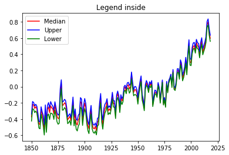

```python
y = temp_ana['Median (℃)']
y2 = temp_ana['Upper (℃)']
y3 = temp_ana['Lower (℃)']
x = temp_ana['Year']
fig = plt.figure()
ax = plt.subplot(111)
ax.plot(x, y, color='r', label='Median')
ax.plot(x, y2, color='b', label='Upper')
ax.plot(x, y3, color='g', label='Lower')
plt.title('Legend inside')
ax.legend()
plt.show()
```

## CO2 in the atmosphere

### Loading Dataset

```python
co2_conc = pd.read_csv('co2-concentration-long-term.csv')
```

```python
co2_conc.head()
```

|  | Entity | Code | Year | CO₂ concentration (parts per million) |
| --- | --- | --- | --- | --- |
| 0 | World | OWID_WRL | 1900 | 294.22 |
| 1 | World | OWID_WRL | 1902 | 295.61 |
| 2 | World | OWID_WRL | 1904 | 295.99 |
| 3 | World | OWID_WRL | 1905 | 299.02 |
| 4 | World | OWID_WRL | 1906 | 298.48 |

### Line Plot of CO2 Concentration

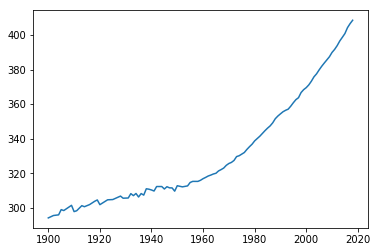

```python
x = co2_conc['Year']
y = co2_conc['CO₂ concentration (parts per million)']
plt.plot(x,y)
plt.show()
```

### Per capita co2 emissions

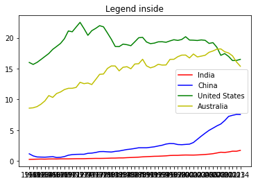

```python
y = data_t['India']
y2 = data_t['China']
y3 = data_t['United States']
y4 = data_t['Australia']
x = data_t['Unnamed: 0']
fig = plt.figure()
ax = plt.subplot(111)
ax.plot(x, y, color='r', label='India')
ax.plot(x, y2, color='b', label='China')
ax.plot(x, y3, color='g', label='United States')
ax.plot(x, y4, color='y', label='Australia')
plt.title('Legend inside')
ax.legend()
plt.show()
```

### Production vs Consumption based CO2 emissions

### Loading Dataset for India

```python
indpc = pd.read_csv('india_prod_cons.csv')
```

```python
indpc.head()
```

|  | Entity | Code | Year | Consumption-based (tonnes) | Production-based (tonnes ) |
| --- | --- | --- | --- | --- | --- |
| 0 | India | IND | 1990 | 614876964 | 616579098.4 |
| 1 | India | IND | 1991 | 650371329 | 656740892.9 |
| 2 | India | IND | 1992 | 682968385 | 698756949.7 |
| 3 | India | IND | 1993 | 701967773 | 722894259.4 |
| 4 | India | IND | 1994 | 738988841 | 764241966.7 |

### Consumption-based VS Production-based

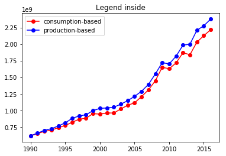

```python
x = indpc['Year']
y1 = indpc['Consumption-based (tonnes)']
y2 = indpc['Production-based (tonnes )']
fig = plt.figure()
ax = plt.subplot(111)
ax.plot(x, y1, marker='o', color='r', label='consumption-based')
ax.plot(x, y2, marker='o', color='b', label='production-based')
plt.title('Legend inside')
ax.legend()
plt.show()
```

### Loading Dataset for United States

```python
uspc = pd.read_csv('us_prod_cons.csv')
```

```python
uspc.head()
```

|  | Entity | Code | Year | Consumption-based (tonnes) | Production-based (tonnes ) |
| --- | --- | --- | --- | --- | --- |
| 0 | United States | USA | 1990 | 5.095538e+09 | 5121264461 |
| 1 | United States | USA | 1991 | 5.057297e+09 | 5070839400 |
| 2 | United States | USA | 1992 | 5.130381e+09 | 5174059076 |
| 3 | United States | USA | 1993 | 5.260585e+09 | 5284687882 |
| 4 | United States | USA | 1994 | 5.364361e+09 | 5377987137 |

### Consumption-based VS Production-based

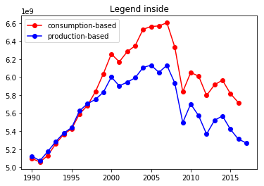

```python
x = uspc['Year']
y1 = uspc['Consumption-based (tonnes)']
y2 = uspc['Production-based (tonnes )']
fig = plt.figure()
ax = plt.subplot(111)
ax.plot(x, y1, marker='o', color='r', label='consumption-based')
ax.plot(x, y2, marker='o', color='b', label='production-based')
plt.title('Legend inside')
ax.legend()
plt.show()
```

### CO2 Emissions by Afghanistan from 1960 to 2014

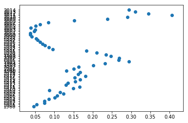

```python
x=data_t['Afghanistan']
y=data_t["Unnamed: 0"]
plt.scatter(x,y)
```

```python
data_t.columns
```

```
Index(['Aruba', 'Afghanistan', 'Angola', 'Albania', 'Andorra', 'Arab World',
       'United Arab Emirates', 'Argentina', 'Armenia', 'American Samoa',
       ...
       'Vietnam', 'Vanuatu', 'World', 'Samoa', 'Kosovo', 'Yemen, Rep.',
       'South Africa', 'Zambia', 'Zimbabwe', 'Unnamed: 0'],
      dtype='object', name=0, length=265)
```

### CO2 emissions by China over 1960 to 2014

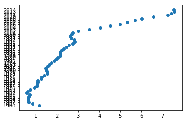

```python
x=data_t['China']
y=data_t["Unnamed: 0"]
plt.scatter(x,y)
```

### CO2 emissions by India over 1960 to 2014

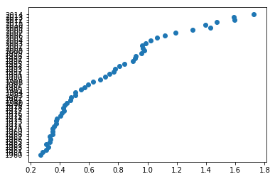

```python
x=data_t['India']
y=data_t["Unnamed: 0"]
plt.scatter(x,y)
```

### CO2 emissions by Austria over 1960 to 2014

[figure not shown]

```python
x=data_t['Austria']
y=data_t["Unnamed: 0"]
plt.scatter(x,y)
```

### CO2 emissions by Australia over 1960 to 2014

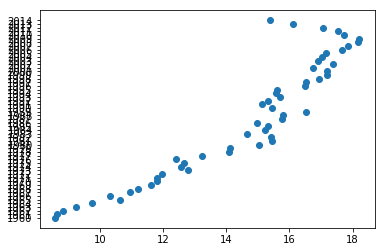

```python
x=data_t['Australia']
y=data_t["Unnamed: 0"]
plt.scatter(x,y)
```

### Total emission by each country from 1960 to 2014

```python
sum = data_t.sum(axis = 0, skipna = True)
csum = list(data_t.sum(axis = 0, skipna = True))
sum
```

```
0
Aruba                                                 5.941065e+02
Afghanistan                                           8.001857e+00
Angola                                                3.424782e+01
Albania                                               9.109183e+01
Andorra                                               1.722227e+02
Arab World                                            1.629673e+02
United Arab Emirates                                  1.687914e+03
Argentina                                             2.010458e+02
Armenia                                               3.091456e+01
American Samoa                                        0.000000e+00
Antigua and Barbuda                                   2.883622e+02
Australia                                             7.993012e+02
Austria                                               3.959376e+02
Azerbaijan                                            9.623343e+01
Burundi                                               1.625299e+00
Belgium                                               6.169107e+02
Benin                                                 1.149673e+01
Burkina Faso                                          3.707374e+00
Bangladesh                                            8.591092e+00
Bulgaria                                              3.908807e+02
Bahrain                                               1.115658e+03
Bahamas, The                                          6.958991e+02
Bosnia and Herzegovina                                9.196772e+01
Belarus                                               1.445113e+02
Belize                                                7.396000e+01
Bermuda                                               4.146443e+02
Bolivia                                               5.174011e+01
Brazil                                                8.136473e+01
Barbados                                              1.769476e+02
Brunei Darussalam                                     1.156867e+03
                                                         ...
Timor-Leste                                           2.935127e+00
Middle East & North Africa (IDA & IBRD countries)     1.370087e+02
Tonga                                                 3.612899e+01
South Asia (IDA & IBRD)                               3.475567e+01
Sub-Saharan Africa (IDA & IBRD countries)             4.716935e+01
Trinidad and Tobago                                   9.137494e+02
Tunisia                                               8.423380e+01
Turkey                                                1.332417e+02
```

[output cut: 8 more lines]

```
St. Vincent and the Grenadines                        5.176460e+01
Venezuela, RB                                         3.316077e+02
British Virgin Islands                                1.976645e+02
Virgin Islands (U.S.)                                 0.000000e+00
Vietnam                                               3.494626e+01
Vanuatu                                               2.729654e+01
World                                                 2.272533e+02
Samoa                                                 3.375008e+01
Kosovo                                                0.000000e+00
Yemen, Rep.                                           4.019929e+01
South Africa                                          4.500851e+02
Zambia                                                2.477069e+01
Zimbabwe                                              6.167373e+01
Unnamed: 0                                           1.960196e+219
Length: 265, dtype: float64
```

### Sorting Countries based on their total CO2 emission over the years

```python
csum.sort()
```

```python
for i in csum:
    print(i)
```

```
0.0
0.0
0.0
0.0
0.0
0.0
0.0
0.0
0.0
0.0
0.0
0.0
0.41324479999999997
1.6252991970000004
1.8207846579999996
2.9051108579999996
2.9351273219999996
2.991860875
3.3091696339999994
3.707373693
3.731884158000001
4.022468514
4.088905266
4.201043971
4.217498043000001
4.395982758
4.854540196
5.228169947000002
6.143878789
6.687535602
6.703191675000001
7.053863982999999
7.742804441
7.941278505999998
7.963978742999998
8.001856881999998
8.232284533
8.326748893
8.591091982999998
9.370148629000001
```

[output cut: 210 more lines]

```
680.1748258770002
681.4219308510001
695.8990888319998
799.3011790969999
867.7357318100002
913.7494409929999
1034.5033504099997
1052.4220296599997
1115.6584045289999
1156.8674451480001
1479.7566319419998
1522.3606617799999
1687.9140905799995
2973.713766998
1.9601961196219632e+219
```

```python
sum_dict = sum.to_dict()
sum_dict.values()
```

```
dict_values([594.106526301, 8.001856881999998, 34.247821779000006, 91.091831321, 172.22268162499998, 162.967348896, 1687.9140905799995, 201.04576459299994, 30.914555544, 0.0, 288.36222488, 799.3011790969999, 395.93758932200006, 96.23342883999997, 1.6252991970000004, 616.910715429, 11.496727855, 3.70…
```

```python
import operator
#print('Original dictionary : ',sum_dict)
sorted_d = dict(sorted(sum_dict.items(), key=operator.itemgetter(1)))
print('Dictionary in ascending order by value : ',sorted_d)
```

```
Dictionary in ascending order by value :  {'American Samoa': 0.0, 'Channel Islands': 0.0, 'Guam': 0.0, 'Isle of Man': 0.0, 'Not classified': 0.0, 'St. Martin (French part)': 0.0, 'Monaco': 0.0, 'Northern Mariana Islands': 0.0, 'Puerto Rico': 0.0, 'San Marino': 0.0, 'Virgin Islands (U.S.)': 0.0, 'Kos…
```

```python
{key:val for key, val in sorted_d.items() if val > 228.61065337700003}
del sorted_d['Unnamed: 0']
```

### Top 10 Countries with Highest Total CO2 emission between 1960-2014

```python
s = len(sorted_d)
res = dict(list(sorted_d.items())[s-10: s])
```

### Bar plot for top 10 CO2 emitting countries

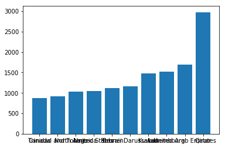

```python
plt.bar(range(len(res)), res.values(), align='center')
plt.xticks(range(len(res)), list(res.keys()))
plt.show()
```

##### Qatar is the highest total C02 emitting country but from the graph we can see that Qatar has reduced its CO2 emissions over the years

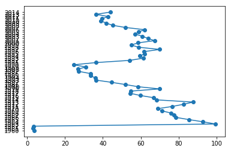

```python
x=data_t['Qatar']
y=data_t["Unnamed: 0"]
plt.scatter(x,y)
plt.plot(x,y)
```

##### Brunei Darussalam is the 5th highest total C02 emitting country but from the graph we can see that Brunei Darussalam has reduced its CO2 emissions over the years

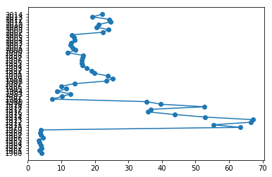

```python
x = data_t['Brunei Darussalam']
y = data_t["Unnamed: 0"]
plt.scatter(x,y)
plt.plot(x,y)
```

### Co2 emission by fossil fuels

### Loading the Fossil fuels dataset

```python
source = pd.read_csv('source.csv')
```

```python
source.head()
```

|  | Entity | Code | Year | Cement (tonnes) | Flaring (tonnes) | Oil (tonnes) | Coal (tonnes) | Gas (tonnes) |
| --- | --- | --- | --- | --- | --- | --- | --- | --- |
| 0 | United States | USA | 1950 | 19569424 | 43121616 | 896800640 | 1257231984 | 319218672 |
| 1 | United States | USA | 1951 | 21199904 | 42700256 | 960660496 | 1211596864 | 376208528 |
| 2 | United States | USA | 1952 | 21471040 | 45682752 | 1000968160 | 1074174880 | 402787184 |
| 3 | United States | USA | 1953 | 22749776 | 43619920 | 1050080416 | 1065956528 | 423342224 |
| 4 | United States | USA | 1954 | 23442272 | 38951984 | 1063212192 | 913446192 | 443999856 |

### Graph to show CO2 emission by different types of fossil fuels.

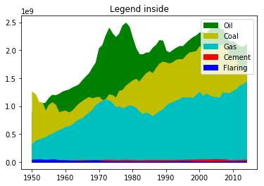

```python
y = source['Cement (tonnes)']
y2 = source['Flaring (tonnes)']
y3 = source['Oil (tonnes)']
y4 = source['Coal (tonnes)']
y5 = source['Gas (tonnes)']
x = source['Year']
fig = plt.figure()
ax = plt.subplot(111)
ax.fill_between(x, y3, color='g', label='Oil')
ax.fill_between(x, y4, color='y', label='Coal')
ax.fill_between(x, y5, color='c', label='Gas')
ax.fill_between(x, y, color='r', label='Cement')
ax.fill_between(x, y2, color='b', label='Flaring')
plt.title('Legend inside')
ax.legend()
plt.show()
```

#### From the above graph it is clear that Oil is the highest producer of fossil fuels followed by coal and gas while cement and flaring being the lowest emitters.

### Co2 emission by sector

### Loading The Dataset

```python
sector = pd.read_csv('sector.csv')
```

```python
sector.head()
```

|  | Entity | Code | Year | Transport (%) | Electricity and heat production (%) | Manufacturing industries & construction (%) | Other sectors (%) | Residential buildings & commercial and public services (%) |
| --- | --- | --- | --- | --- | --- | --- | --- | --- |
| 0 | China | CHN | 1971 | 5.826935 | 17.371855 | 48.745786 | 6.458849 | 21.596575 |
| 1 | China | CHN | 1972 | 6.028603 | 17.687672 | 48.376776 | 6.577096 | 21.329853 |
| 2 | China | CHN | 1973 | 6.296433 | 18.469230 | 47.693661 | 6.710718 | 20.831115 |
| 3 | China | CHN | 1974 | 6.673472 | 17.990246 | 48.254508 | 6.761937 | 20.318703 |
| 4 | China | CHN | 1975 | 6.402472 | 18.574940 | 48.051570 | 6.504484 | 20.465564 |

```python
sector.columns
```

```
Index(['Entity', 'Code', 'Year', 'Transport (%)',
       'Electricity and heat production (%)',
       'Manufacturing industries & construction (%)', 'Other sectors (%)',
       'Residential buildings & commercial and public services (%)'],
      dtype='object')
```

### Graph to show CO2 emission by different sectors.

[figure not shown]

```python
y = sector['Transport (%)']
y2 = sector['Electricity and heat production (%)']
y3 = sector['Manufacturing industries & construction (%)']
y4 = sector['Other sectors (%)']
y5 = sector['Residential buildings & commercial and public services (%)']
x = sector['Year']
fig = plt.figure()
ax = plt.subplot(111)
ax.fill_between(x, y3, color='g', label='Transport')
ax.fill_between(x, y2, color='b', label='Electricity')
ax.fill_between(x, y5, color='c', label='Manufacturing')
ax.fill_between(x, y, color='r', label='Others')
ax.fill_between(x, y4, color='y', label='Residential')
plt.title('Legend inside')
ax.legend()
plt.show()
```

### CO2 emissions by country

#### China

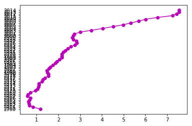

```python
x = data_t['China']
y = data_t["Unnamed: 0"]
plt.plot(x,y, marker='o', color='m')
```

#### India

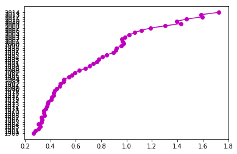

```python
x = data_t['India']
y = data_t["Unnamed: 0"]
plt.plot(x,y, marker='o', color='m')
```

#### United States

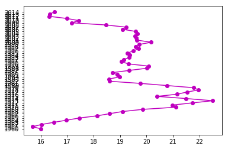

```python
x = data_t['United States']
y = data_t["Unnamed: 0"]
plt.plot(x,y, marker='o', color='m')
```

#### Qatar

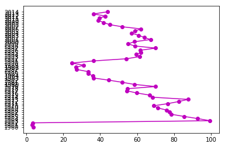

```python
x = data_t['Qatar']
y = data_t["Unnamed: 0"]
plt.plot(x,y, marker='o', color='m')
```

### Global CO2 Concentrations

```python
global_ppm = pd.read_csv('global-co-concentration-ppm.csv')
```

```python
global_ppm.head()
```

|  | Entity | Code | Year | CO₂ concentration (parts per million) |
| --- | --- | --- | --- | --- |
| 0 | World | OWID_WRL | 1723 | 277.64 |
| 1 | World | OWID_WRL | 1734 | 278.31 |
| 2 | World | OWID_WRL | 1741 | 276.81 |
| 3 | World | OWID_WRL | 1749 | 277.60 |
| 4 | World | OWID_WRL | 1752 | 277.23 |

```python
global_ppm.columns
```

```
Index(['Entity', 'Code', 'Year', 'CO₂ concentration (parts per million)'], dtype='object')
```

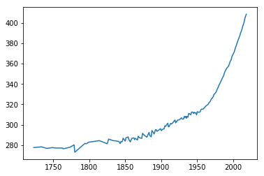

```python
x = global_ppm['Year']
y = global_ppm['CO₂ concentration (parts per million)']
plt.plot(x,y)
```

```python
co_conc = pd.read_csv('co2-concentration-long-term.csv')
```

```python
co_conc.head()
```

|  | Entity | Code | Year | CO₂ concentration (parts per million) |
| --- | --- | --- | --- | --- |
| 0 | World | OWID_WRL | 1900 | 294.22 |
| 1 | World | OWID_WRL | 1902 | 295.61 |
| 2 | World | OWID_WRL | 1904 | 295.99 |
| 3 | World | OWID_WRL | 1905 | 299.02 |
| 4 | World | OWID_WRL | 1906 | 298.48 |

```python
co_conc.columns
```

```
Index(['Entity', 'Code', 'Year', 'CO₂ concentration (parts per million)'], dtype='object')
```

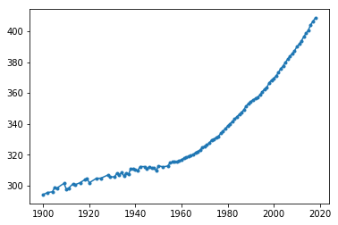

```python
x = co_conc['Year']
y = co_conc['CO₂ concentration (parts per million)']
plt.plot(x,y, marker='.')
```

### Data Shape

```python
data_t.shape
```

```
(55, 265)
```

### India Prediction Using Polynomial Regression

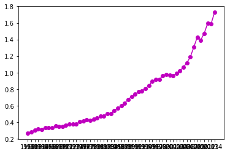

```python
x = data_t["Unnamed: 0"]
y = data_t['India']
plt.plot(x,y, marker='o', color='m')
```

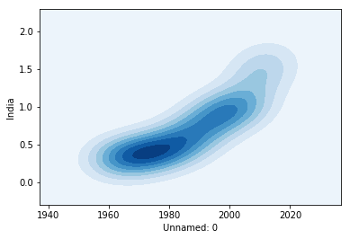

```python
import seaborn as sns
sns.kdeplot(data_t['Unnamed: 0'], data_t['India'], cmap="Blues", shade=True, shade_lowest=True, )
```

### Training the Model

```python
# Polynomial Regression
# Importing the dataset
X = data_t.iloc[:, 264:265].values
y = data_t.iloc[:, 107:108].values

# Splitting the dataset into the Training set and Test set
from sklearn.model_selection import train_test_split
X_train, X_test, y_train, y_test = train_test_split(X, y, test_size = 0.2, random_state = 0)
# Feature Scaling


# Fitting Linear Regression to the dataset
from sklearn.linear_model import LinearRegression
lin_reg = LinearRegression()
lin_reg.fit(X, y)

# Fitting Polynomial Regression to the dataset
from sklearn.preprocessing import PolynomialFeatures
poly_reg = PolynomialFeatures(degree = 4)
X_poly = poly_reg.fit_transform(X)
poly_reg.fit(X_poly, y)
lin_reg_2 = LinearRegression()
lin_reg_2.fit(X_poly, y)

##lin_reg_2.predict(poly_reg.fit_transform(X_test))
X_test
```

```
array([['2005'],
       ['1993'],
       ['2000'],
       ['1986'],
       ['1971'],
       ['1962'],
       ['1992'],
       ['2003'],
       ['2006'],
       ['1990'],
       ['1964']], dtype=object)
```

##### India Predictions

```python
lin_reg_2.predict(poly_reg.fit_transform(X_test))
```

```
array([[1.1645873 ],
       [0.73693071],
       [0.95954964],
       [0.57600671],
       [0.3705035 ],
       [0.29120357],
       [0.71051012],
       [1.07753283],
       [1.21076595],
       [0.66127266],
       [0.30812129]])
```

```python
india_pred = lin_reg_2.predict(poly_reg.fit_transform(X))
```

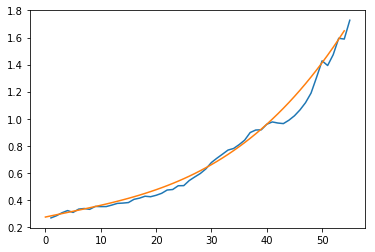

```python
plt.plot(y)
plt.plot(india_pred)
plt.show()
```

#### From the above graph we can see the accuracy of our model. Orange line is the predicted data while the blue line is the original data.

### China Prediction Using Polynomial Regression

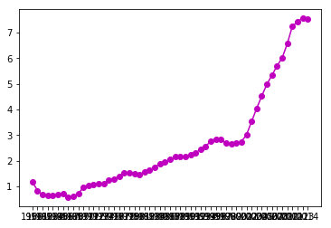

```python
x = data_t["Unnamed: 0"]
y = data_t['China']
plt.plot(x,y, marker='o', color='m')
```

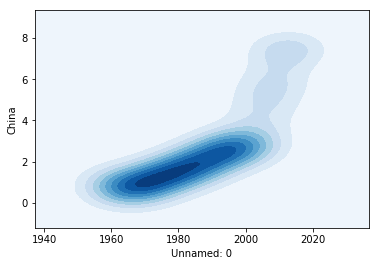

```python
sns.kdeplot(data_t['Unnamed: 0'], data_t['China'], cmap="Blues", shade=True, shade_lowest=True, )
```

### Training the Model

```python
# Polynomial Regression

# Importing the libraries
import numpy as np
import matplotlib.pyplot as plt
import pandas as pd

# Importing the dataset
X = data_t.iloc[:, 264:265].values
y = data_t.iloc[:, 38:39].values

# Splitting the dataset into the Training set and Test set
from sklearn.model_selection import train_test_split
X_train, X_test, y_train, y_test = train_test_split(X, y, test_size = 0.2, random_state = 0)

# Fitting Linear Regression to the dataset
from sklearn.linear_model import LinearRegression
lin_reg = LinearRegression()
lin_reg.fit(X, y)

# Fitting Polynomial Regression to the dataset
from sklearn.preprocessing import PolynomialFeatures
poly_reg = PolynomialFeatures(degree = 4)
X_poly = poly_reg.fit_transform(X)
poly_reg.fit(X_poly, y)
lin_reg_2 = LinearRegression()
lin_reg_2.fit(X_poly, y)

##lin_reg_2.predict(poly_reg.fit_transform(X_test))
X_test
```

```
array([['2005'],
       ['1993'],
       ['2000'],
       ['1986'],
       ['1971'],
       ['1962'],
       ['1992'],
       ['2003'],
       ['2006'],
       ['1990'],
       ['1964']], dtype=object)
```

```python
lin_reg_2.predict(poly_reg.fit_transform(X_test))
```

```
array([[4.56006083],
       [2.24825934],
       [3.3388901 ],
       [1.6759622 ],
       [1.16047338],
       [0.60288099],
       [2.13999752],
       [4.02076799],
       [4.85711186],
       [1.9525841 ],
       [0.7753469 ]])
```

```python
china_pred = lin_reg_2.predict(poly_reg.fit_transform(X))
```

##### Prediction vs real values

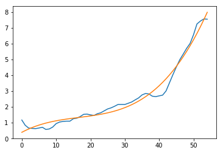

```python
plt.plot(y)
plt.plot(china_pred)
plt.show()
```

### United States Prediction Using Random Forest Regression

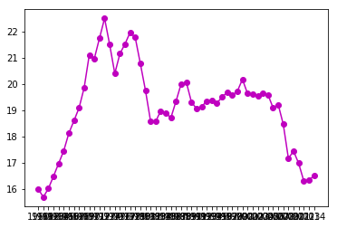

```python
x = data_t["Unnamed: 0"]
y = data_t['United States']
plt.plot(x,y, marker='o', color='m')
```

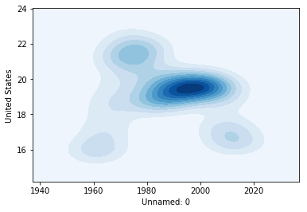

```python
sns.kdeplot(data_t['Unnamed: 0'], data_t['United States'], cmap="Blues", shade=True, shade_lowest=True, )
```

### Training The model

```python
X = data_t.iloc[:, 264:265].values
y = data_t.iloc[:, 249:250].values

# Splitting the dataset into the Training set and Test set
from sklearn.model_selection import train_test_split
X_train, X_test, y_train, y_test = train_test_split(X, y, test_size = 0.2, random_state = 0)

print(X_test)

# Fitting Random Forest Regression to the dataset
from sklearn.ensemble import RandomForestRegressor
regressor = RandomForestRegressor(n_estimators = 10, random_state = 0)
regressor.fit(X, y)

# Predicting a new result
y_pred = regressor.predict([['2019']])
y_pred
```

```
[['2005']
 ['1993']
 ['2000']
 ['1986']
 ['1971']
 ['1962']
 ['1992']
 ['2003']
 ['2006']
 ['1990']
 ['1964']]
```

```
array([16.41185645])
```

```python
us_pred = regressor.predict(X)
```

##### Prediction vs Real Values

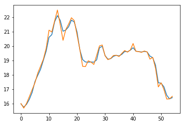

```python
plt.plot(us_pred)
plt.plot(y)
plt.show()
```

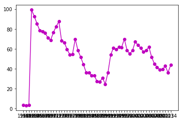

```python
x = data_t["Unnamed: 0"]
y = data_t['Qatar']
plt.plot(x,y, marker='o', color='m')
```

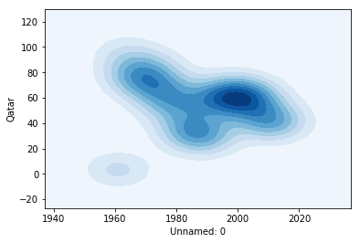

```python
sns.kdeplot(data_t['Unnamed: 0'], data_t['Qatar'], cmap="Blues", shade=True, shade_lowest=True, )
```

```python
data_t.iloc[:, 198:199]
```

|  | Qatar |
| --- | --- |
| 1 | 3.71467 |
| 2 | 3.13778 |
| 3 | 3.38921 |
| 4 | 99.4646 |
| 5 | 92.8609 |
| 6 | 85.4586 |
| 7 | 78.6252 |
| 8 | 77.5024 |
| 9 | 75.9672 |
| 10 | 71.0987 |
| 11 | 69.1116 |
| 12 | 76.6479 |
| 13 | 82.641 |
| 14 | 87.6866 |
| 15 | 68.2694 |
| 16 | 66.6808 |
| 17 | 59.7794 |
| 18 | 54.4465 |
| 19 | 54.8662 |
| 20 | 69.9903 |
| 21 | 58.5718 |
| 22 | 51.858 |
| 23 | 44.5634 |
| 24 | 36.4322 |
| 25 | 36.1358 |
| 26 | 33.4478 |
| 27 | 33.4302 |
| 28 | 27.2409 |
| 29 | 26.8905 |
| 30 | 31.0316 |
| 31 | 24.7224 |
| 32 | 36.3274 |
| 33 | 54.1025 |
| 34 | 61.263 |
| 35 | 59.6074 |
| 36 | 61.914 |
| 37 | 61.8125 |
| 38 | 70.0422 |
| 39 | 58.7452 |
| 40 | 55.0543 |
| 41 | 58.6195 |
| 42 | 67.3105 |
| 43 | 63.8281 |
| 44 | 60.9008 |
| 45 | 57.0056 |
| 46 | 58.8811 |
| 47 | 62.0662 |
| 48 | 51.9337 |
| 49 | 45.1348 |
| 50 | 41.8272 |
| 51 | 39.0597 |
| 52 | 39.5092 |
| 53 | 42.8604 |
| 54 | 36.3879 |
| 55 | 43.8573 |

### Training the model

```python
X = data_t.iloc[:, 264:265].values
y = data_t.iloc[:, 198:199].values

# Splitting the dataset into the Training set and Test set
from sklearn.model_selection import train_test_split
X_train, X_test, y_train, y_test = train_test_split(X, y, test_size = 0.2, random_state = 0)

print(X_test)

# Fitting Random Forest Regression to the dataset
from sklearn.ensemble import RandomForestRegressor
regressor = RandomForestRegressor(n_estimators = 10, random_state = 0)
regressor.fit(X, y)

# Predicting a new result
y_pred = regressor.predict(X_test)
y_pred
```

```
[['2005']
 ['1993']
 ['2000']
 ['1986']
 ['1971']
 ['1962']
 ['1992']
 ['2003']
 ['2006']
 ['1990']
 ['1964']]
```

```
array([58.89550535, 58.94931215, 58.93159284, 32.19589471, 73.7188247 ,
        3.33892863, 50.54747548, 61.73771207, 59.77889318, 27.67432389,
       74.88667985])
```

##### Prediction vs Real VALUES

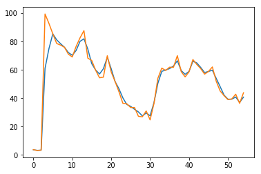

```python
qatar_pred = regressor.predict(X)
plt.plot(qatar_pred)
plt.plot(y)
plt.show()
```